# Model Prediction Test Documentation

Avner Freiberger

# About the App

## Model Prediction Test

Model prediction test is a simple tool to visualise and test prediction models

## What can you define?

in order to test the various models you can:

- select a dataset to test
- define a training and testing set subsets
- select a model to test
- select the argument that will be participating
- review prediction results in a plot, confusion matrix or summary

## Datasets available

the datasets available in the app are R

- **spam:** A dataset collected at Hewlett-Packard Labs, that classifies 4601 e-mails as spam or non-spam.
- **mtcars:** A dataset extracted from the 1974 Motor Trend US magazine, and comprises fuel consumption and 10 aspects of automobile
- **iris:** A famous (Fisher’s or Anderson’s) iris dataset which gives the measurements in centimeters of the variables sepal length and width and petal length and width
- **OrchardSparys:** An experiment which was conducted to assess the potency of various constituents of orchard sprays in repelling honeybees
- **swiss:** Standardized fertility measure and socio-economic indicators for each of 47 French-speaking provinces of Switzerland at about 1888

## Models available

The following models are available for testing

- **glm:** generalized linear model
- **k Nearest Neighbours**
- **Neural Network**
- **lm:** linear model
- **rpart:** recursive partitioning and regression trees

# Usage

## 1. Select a dataset:

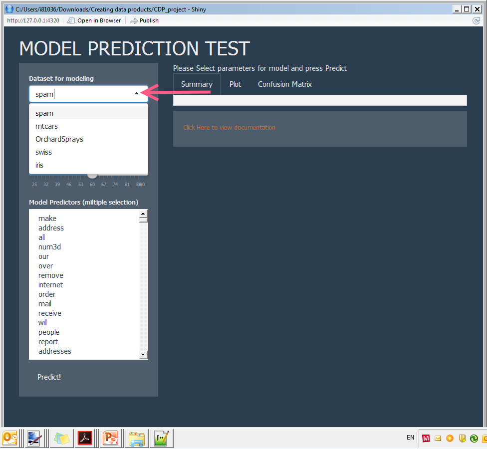

## 2. Select a classification algorithm

## 3. Set the percentage of training set (the rest will be set as a testing set)

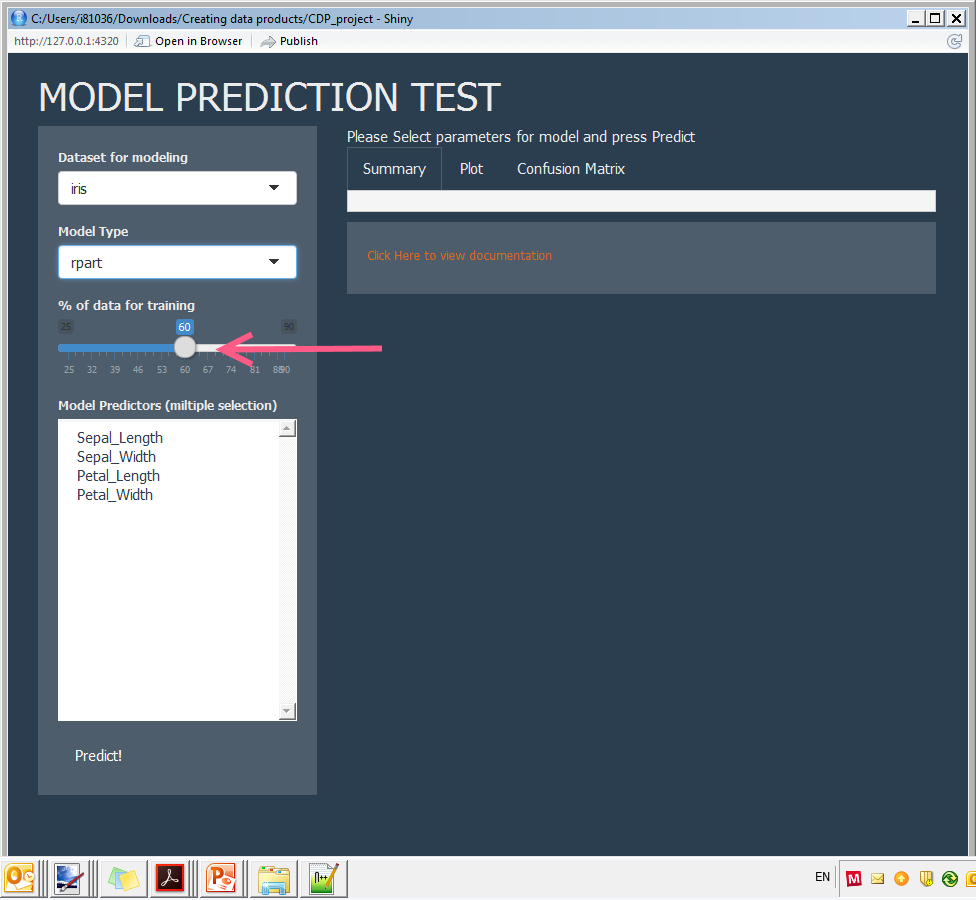

## 4. Select the prdictors that you want to include in your model (use Ctrl or Shift to select multiple predictors)

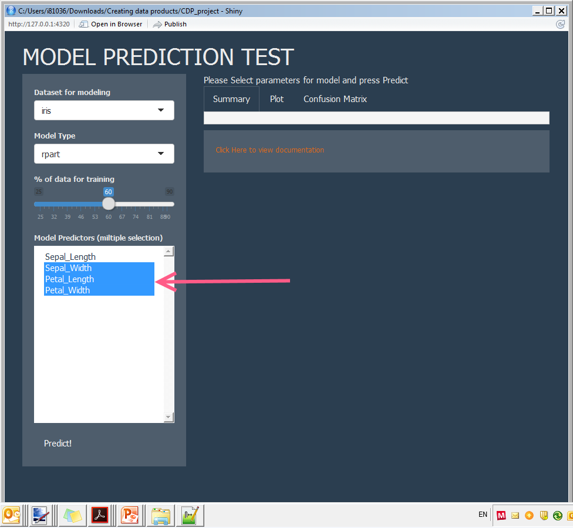

## 5. press “Predict!” keep in mind that some models will take a while. in addition not all models are applicable for all of the data sets

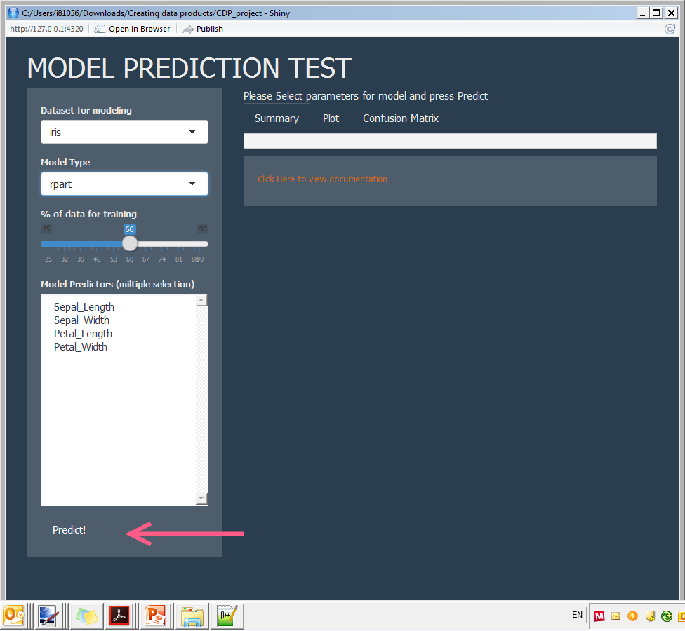

## 6. review results, you can see

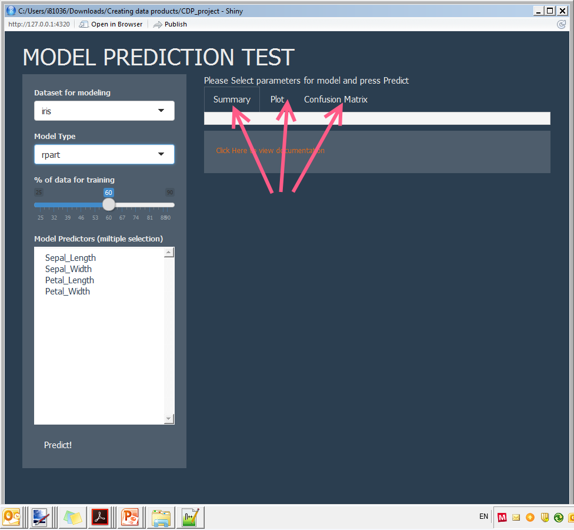

you can change plot X and Y predictor to further estimate the prediction

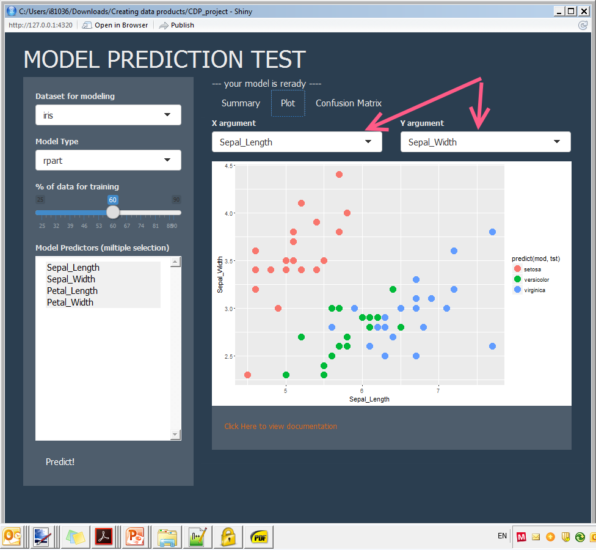